# R Notebook

# Exercise 17.13

```r
read1713 <- read.csv("D:\\Xr17-13.csv")
data1713 <- data.frame(read1713)
```

## 1. Plot the scatter diagram

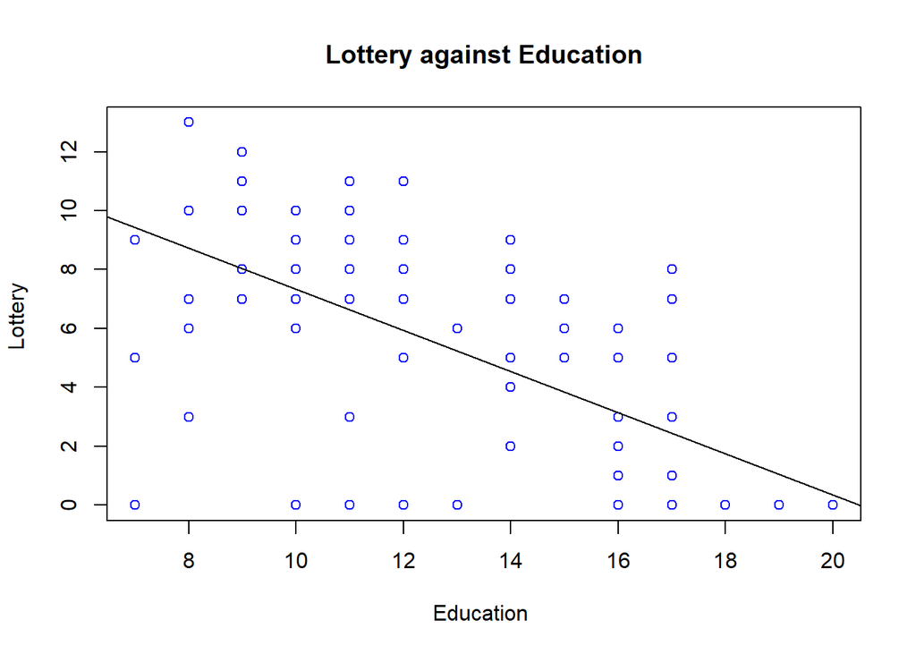

```r
Lottery <- read1713$Lottery
Education <- read1713$Education
n <- length(Lottery)
plot(Education, Lottery, col = "blue", main = "Lottery against Education", xlab = "Education ", ylab = "Lottery ")
abline(lm(Lottery ~ Education))
```

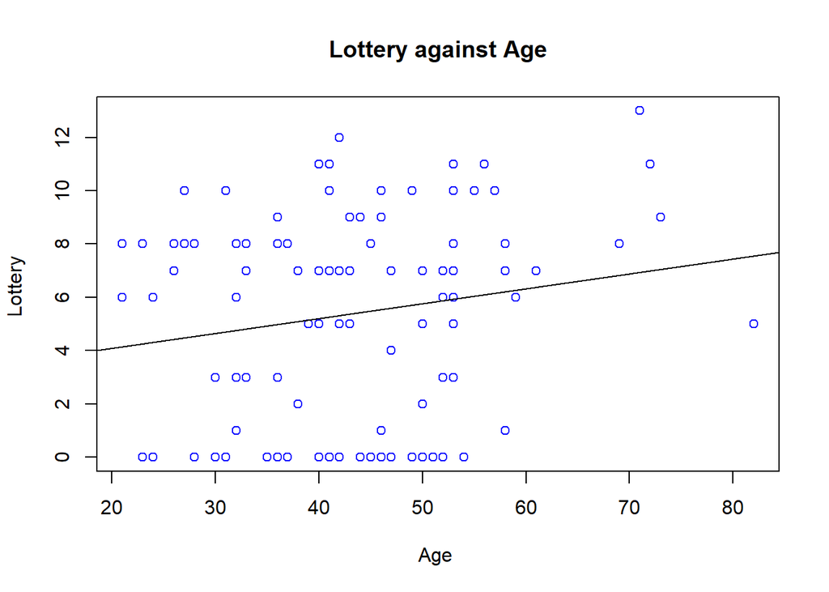

```r
Lottery <- read1713$Lottery
Age <- read1713$Age
n <- length(Lottery)
plot(Age, Lottery, col = "blue", main = "Lottery against Age", xlab = "Age ", ylab = "Lottery ")
abline(lm(Lottery ~ Age))
```

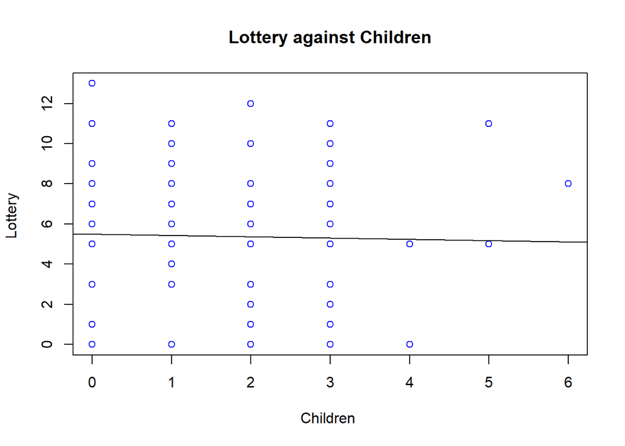

```r
Lottery <- read1713$Lottery
Children <- read1713$Children
n <- length(Lottery)
plot(Children, Lottery, col = "blue", main = "Lottery against Children", xlab = "Children ", ylab = "Lottery ")
abline(lm(Lottery ~ Children))
```

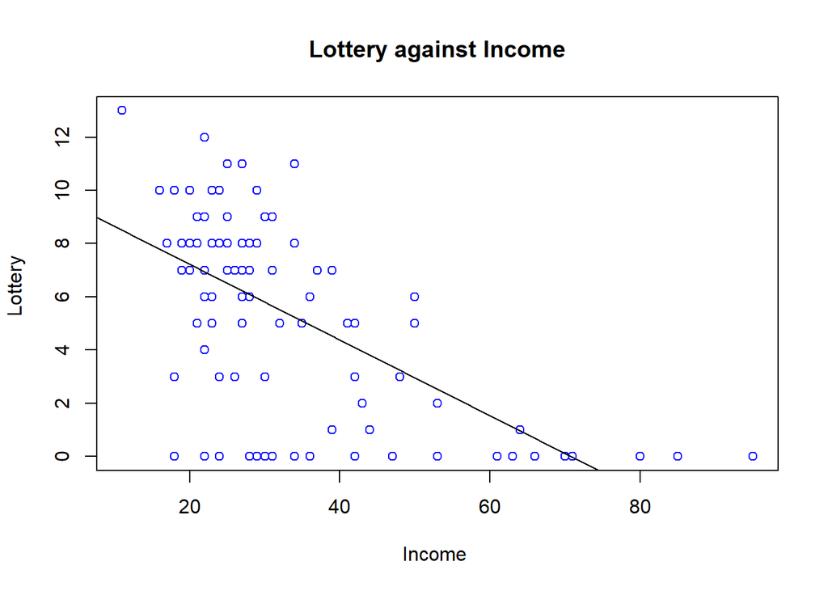

```r
Lottery <- read1713$Lottery
Income <- read1713$Income
n <- length(Lottery)
plot(Income, Lottery, col = "blue", main = "Lottery against Income", xlab = "Income ", ylab = "Lottery ")
abline(lm(Lottery ~ Income))
```

## 2. Propose a statistical model

Suppose that number of years of education (in year) (x1), age (in year)(x2), tnumber of children (count)(x3), personal income (in thousands of dollars)(x4) and the error$\epsilon$ by the following regression model:
$$y = \beta_0 + \beta_1x_1 + \beta_2x_2 + \beta_3x_3 + \beta_4x_4 + \epsilon$$
y = amount spent on lottery tickets as a percentage of total household income (in percentage point). x1 = number of years of education (in year). x2 = age (in year). x3 = number of children (count), x4 = personal income (in thousands of dollars). ε = error variable.

## 3. Fit the model

```r
n <- length(Lottery)
Data.read1713 <- cbind(Education, Age, Children, Income)
linearModelVar <- lm(Lottery ~ Data.read1713)
cat("# # # # The regression model # # # ","\n")
```

```
## # # # # The regression model # # #
```

```r
print(summary(linearModelVar))
```

```
##
## Call:
## lm(formula = Lottery ~ Data.read1713)
##
## Residuals:
##     Min      1Q  Median      3Q     Max
## -8.5245 -1.3062  0.2443  1.9294  5.1222
##
## Coefficients:
##                        Estimate Std. Error t value Pr(>|t|)
## (Intercept)            11.90609    1.78520   6.669 1.69e-09 ***
## Data.read1713Education -0.43002    0.13207  -3.256  0.00157 **
## Data.read1713Age        0.02919    0.02523   1.157  0.25015
## Data.read1713Children   0.09344    0.22431   0.417  0.67796
## Data.read1713Income    -0.07447    0.02773  -2.686  0.00854 **
## ---
## Signif. codes:  0 '***' 0.001 '**' 0.01 '*' 0.05 '.' 0.1 ' ' 1
##
## Residual standard error: 2.91 on 95 degrees of freedom
## Multiple R-squared:  0.4335, Adjusted R-squared:  0.4096
## F-statistic: 18.17 on 4 and 95 DF,  p-value: 4.094e-11
```

```r
ANOVA_T_lm <- anova(linearModelVar)
cat("# # # # The ANOVA Table # # # ","\n")
```

```
## # # # # The ANOVA Table # # #
```

```r
print(ANOVA_T_lm)
```

```
## Analysis of Variance Table
##
## Response: Lottery
##               Df Sum Sq Mean Sq F value    Pr(>F)
## Data.read1713  4 615.44 153.861  18.172 4.094e-11 ***
## Residuals     95 804.35   8.467
## ---
## Signif. codes:  0 '***' 0.001 '**' 0.01 '*' 0.05 '.' 0.1 ' ' 1
```

The regression line is y_head = 11.90609−0.43002$x_1$+0.02919$x_2$+0.09344$x_3$−0.07447$x_4$

## 4. Residual analysis

Standardized Residuals

```r
SE <- standarized_errors_MR(Lottery, Data.read1713)[,1]
h <- standarized_errors_MR(Lottery, Data.read1713)[,2]
D <- standarized_errors_MR(Lottery, Data.read1713)[,3]
cat("# # # # The Standardized Errors # # # ","\n")
```

```
## # # # # The Standardized Errors # # #
```

```r
print(SE)
```

```
##   [1]  0.33004815  0.09668659 -2.08301296  0.66913926  0.01714317
##   [6]  0.46644044 -1.92777737 -1.01099557  0.47521128 -0.52332970
##  [11] -0.45800007 -0.27349124  1.45856331  0.21708026  0.94211885
##  [16] -0.38873674  1.83270262 -0.58969039 -0.35846750 -0.45819280
##  [21]  0.61724153  0.07505467 -0.34433678  1.45082923  0.51108952
##  [26]  0.19738698  1.04325524  0.61570959  0.18335027  0.55750794
##  [31] -0.04523180  1.13245407 -0.81213950 -0.60080438  0.61586027
##  [36]  0.87357304  1.19808758 -0.17068341 -0.05687572 -1.34877924
##  [41] -0.39660735  1.05862232  0.01092105  0.11930291  0.25714857
##  [46] -0.01088334  0.59292361 -1.38308843 -0.10566518  0.58510740
##  [51]  0.25395450 -2.43611693 -0.01354185 -1.12899779  0.10299865
##  [56] -0.28943986  1.71536750  1.12714002 -0.24219279  1.05660139
##  [61] -1.71228985  0.82846718 -2.19896569  1.23938465  0.57065336
##  [66] -2.35242722  0.32702281  0.35376895 -1.41740479  0.19537052
##  [71] -0.46199005  1.36130023 -0.31394490  0.68150208  0.67569327
##  [76] -1.24453969 -0.04006376  0.07031376 -0.03953766 -0.98823158
##  [81] -0.50301613 -0.36093357 -0.31045344  0.83100322  1.19187212
##  [86] -0.03722228 -3.01974735  0.52364182  1.11246830  1.19088802
##  [91]  0.79675737  1.06638728 -1.27082436 -2.23492266 -0.70244908
##  [96] -0.76744065 -1.39697338  0.81569172  1.04778129  1.51794418
```

```r
cat("# # # # hi # # # ","\n")
```

```
## # # # # hi # # #
```

```r
print(h)
```

```
##   [1] 0.01918484 0.05489585 0.02773646 0.02365835 0.02239384 0.01551389
##   [7] 0.05373460 0.02587016 0.14497354 0.02399232 0.05047100 0.07228419
##  [13] 0.02552692 0.02305088 0.07908296 0.02020773 0.07742254 0.04285888
##  [19] 0.03695409 0.11213824 0.02664754 0.02919530 0.09588650 0.03883529
##  [25] 0.04238779 0.03965027 0.04911853 0.07667087 0.04360875 0.03457760
##  [31] 0.03681049 0.04194045 0.04077351 0.04004980 0.02384749 0.03036033
##  [37] 0.03679233 0.05574284 0.12205219 0.02254616 0.06333894 0.03227650
##  [43] 0.05367422 0.03960502 0.13909615 0.02581684 0.02703220 0.03079397
##  [49] 0.03301472 0.03368051 0.04044562 0.03315512 0.03997528 0.01976881
##  [55] 0.12519214 0.04553879 0.09682144 0.06394371 0.03982532 0.01452082
##  [61] 0.15621376 0.18586221 0.05838584 0.04358171 0.02948981 0.02305657
##  [67] 0.07544958 0.05135462 0.06339756 0.03330004 0.02241370 0.03272810
##  [73] 0.07763519 0.03697168 0.05100399 0.03555981 0.01981318 0.02955430
##  [79] 0.07138169 0.07584501 0.03204612 0.10466197 0.04981996 0.03516665
##  [85] 0.03666325 0.02454002 0.05881026 0.04421398 0.03307089 0.10363769
##  [91] 0.04535669 0.03002046 0.03519223 0.02574824 0.03358078 0.03474950
##  [97] 0.09665560 0.03514365 0.06085859 0.03010368
```

```r
cat("# # # # Di # # # ","\n")
```

```
## # # # # Di # # #
```

```r
print(D)
```

```
##   [1] 7.102389e-04 1.809969e-04 4.126004e-02 3.616549e-03 2.244013e-06
##   [6] 1.142831e-03 7.034505e-02 9.048145e-03 1.276325e-02 2.244133e-03
##  [11] 3.716580e-03 1.942647e-03 1.857625e-02 3.706252e-04 2.540695e-02
##  [16] 1.038899e-03 9.395660e-02 5.190291e-03 1.643591e-03 8.838604e-03
##  [21] 3.476771e-03 5.646966e-05 4.191602e-03 2.834915e-02 3.854107e-03
##  [26] 5.362070e-04 1.874040e-02 1.049311e-02 5.109517e-04 3.710721e-03
##  [31] 2.606312e-05 1.871374e-02 9.345381e-03 5.019917e-03 3.088646e-03
##  [36] 7.964771e-03 1.827651e-02 5.732713e-04 1.499027e-04 1.398740e-02
##  [41] 3.545591e-03 1.245937e-02 2.254926e-06 1.956506e-04 3.561291e-03
##  [46] 1.046323e-06 3.255811e-03 2.025948e-02 1.270663e-04 3.977478e-03
##  [51] 9.061340e-04 6.783734e-02 2.545329e-06 8.568741e-03 5.060649e-04
##  [56] 1.332351e-03 1.051456e-01 2.892880e-02 8.109801e-04 5.483335e-03
##  [61] 1.809340e-01 5.223030e-02 9.994250e-02 2.333175e-02 3.298339e-03
##  [66] 4.353479e-02 2.909116e-03 2.258363e-03 4.532980e-02 4.382782e-04
##  [71] 1.631182e-03 2.090060e-02 2.765295e-03 5.943514e-03 8.179330e-03
##  [76] 1.903621e-02 1.081502e-05 5.018904e-05 4.005440e-05 2.671643e-02
##  [81] 2.792309e-03 5.076159e-03 1.684493e-03 8.390016e-03 1.802150e-02
##  [86] 1.161850e-05 1.899310e-01 4.228111e-03 1.410929e-02 5.465813e-02
##  [91] 1.005382e-02 1.173177e-02 1.963612e-02 4.400277e-02 5.715229e-03
##  [96] 7.067680e-03 6.960311e-02 8.078208e-03 2.371434e-02 2.383881e-02
```

Non-normality

$H_0$ :Errors are normally distributed

$H_1$:Errors are not normally distributed

```r
Chi_normal_value <- Chi_Square_Normal_Test(SE, 10)
```

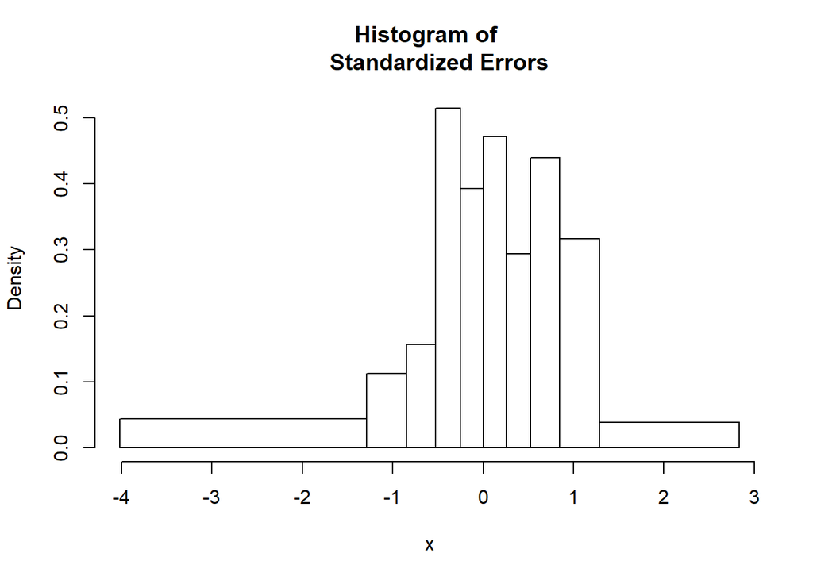

```r
print(Chi_normal_value)
```

```
##  X-squared
## 0.08247516
```

since p_value = 0.08247516 > 0.05. We can assume that errors are normally distributed.

Heteroscedasticity and homoscedasticity

$H_0$:Homoscedasticity

$H_1$:Heteroscedasticity

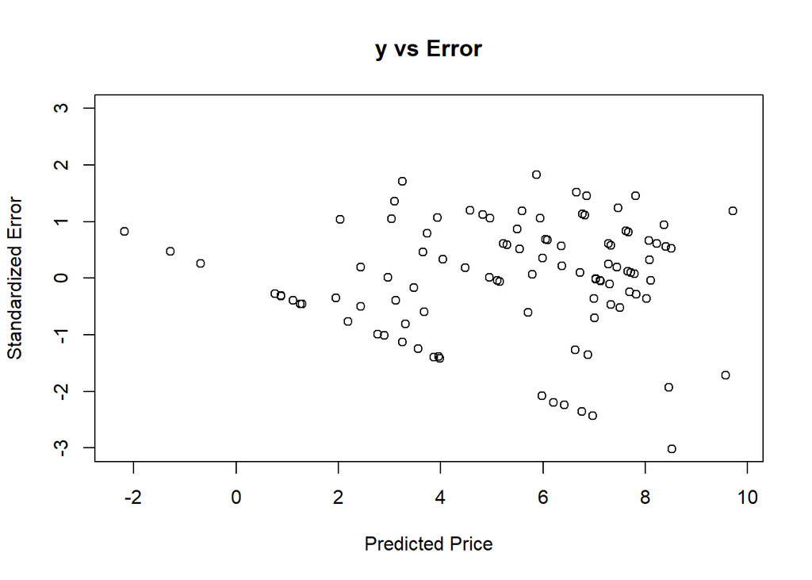

```r
Hetero_plot(Lottery,Data.read1713,4)
```

It appears that the variation is constant and the mean is around 0.

Non-independence of the Error Variable

```r
Run_Test_Result <- Run_Test(SE)
```

```
##   [1]  TRUE  TRUE FALSE  TRUE FALSE  TRUE FALSE FALSE  TRUE FALSE FALSE
##  [12] FALSE  TRUE  TRUE  TRUE FALSE  TRUE FALSE FALSE FALSE  TRUE FALSE
##  [23] FALSE  TRUE  TRUE  TRUE  TRUE  TRUE  TRUE  TRUE FALSE  TRUE FALSE
##  [34] FALSE  TRUE  TRUE  TRUE FALSE FALSE FALSE FALSE  TRUE FALSE  TRUE
##  [45]  TRUE FALSE  TRUE FALSE FALSE  TRUE  TRUE FALSE FALSE FALSE  TRUE
##  [56] FALSE  TRUE  TRUE FALSE  TRUE FALSE  TRUE FALSE  TRUE  TRUE FALSE
##  [67]  TRUE  TRUE FALSE  TRUE FALSE  TRUE FALSE  TRUE  TRUE FALSE FALSE
##  [78] FALSE FALSE FALSE FALSE FALSE FALSE  TRUE  TRUE FALSE FALSE  TRUE
##  [89]  TRUE  TRUE  TRUE  TRUE FALSE FALSE FALSE FALSE FALSE  TRUE  TRUE
## [100]  TRUE
```

```r
cat("     ","\n")
```

```r
cat("# # # # The Run Test # # # ","\n")
```

```
## # # # # The Run Test # # #
```

```r
print(Run_Test_Result)
```

```
## [1] 50.000000 50.000000 51.000000 51.000000  4.974683  0.000000  1.000000
```

Because R = 51 is not out of the unrejected range, do not rejected H0. We can assume that samples are randomly selected.

Outliers and onfluential observations

```r
cat("# # # # Outliers # # # ","\n")
```

```
## # # # # Outliers # # #
```

```r
as.data.frame(data1713[abs(SE) > 2,])
```

|  | Lottery | Education | Age | Children | Income |
| --- | --- | --- | --- | --- | --- |
| 3 | 0 | 13 | 40 | 3 | 24 |
| 52 | 0 | 12 | 44 | 3 | 18 |
| 63 | 0 | 11 | 23 | 0 | 22 |
| 66 | 0 | 10 | 42 | 1 | 29 |
| 87 | 0 | 7 | 37 | 2 | 22 |
| 94 | 0 | 11 | 41 | 3 | 30 |

There are 6 possible outliers, whose values are shown above, since their standardized residuals are bigger than 2 or less than -2.

Influential observation

```r
n <- length(Lottery)
Data.Inn_Profit <- cbind(Education, Age, Children, Income)
h <- standarized_errors_MR(Lottery, Data.Inn_Profit)[,2]
cat("     ","\n")
```

```r
cat("# # # # hii # # # ","\n")
```

```
## # # # # hii # # #
```

```r
print(h)
```

```
##   [1] 0.01918484 0.05489585 0.02773646 0.02365835 0.02239384 0.01551389
##   [7] 0.05373460 0.02587016 0.14497354 0.02399232 0.05047100 0.07228419
##  [13] 0.02552692 0.02305088 0.07908296 0.02020773 0.07742254 0.04285888
##  [19] 0.03695409 0.11213824 0.02664754 0.02919530 0.09588650 0.03883529
##  [25] 0.04238779 0.03965027 0.04911853 0.07667087 0.04360875 0.03457760
##  [31] 0.03681049 0.04194045 0.04077351 0.04004980 0.02384749 0.03036033
##  [37] 0.03679233 0.05574284 0.12205219 0.02254616 0.06333894 0.03227650
##  [43] 0.05367422 0.03960502 0.13909615 0.02581684 0.02703220 0.03079397
##  [49] 0.03301472 0.03368051 0.04044562 0.03315512 0.03997528 0.01976881
##  [55] 0.12519214 0.04553879 0.09682144 0.06394371 0.03982532 0.01452082
##  [61] 0.15621376 0.18586221 0.05838584 0.04358171 0.02948981 0.02305657
##  [67] 0.07544958 0.05135462 0.06339756 0.03330004 0.02241370 0.03272810
##  [73] 0.07763519 0.03697168 0.05100399 0.03555981 0.01981318 0.02955430
##  [79] 0.07138169 0.07584501 0.03204612 0.10466197 0.04981996 0.03516665
##  [85] 0.03666325 0.02454002 0.05881026 0.04421398 0.03307089 0.10363769
##  [91] 0.04535669 0.03002046 0.03519223 0.02574824 0.03358078 0.03474950
##  [97] 0.09665560 0.03514365 0.06085859 0.03010368
```

```r
n <- length(h)
cat("     ","\n")
```

```r
cat("# # # # Influential Observations by h # # # ","\n")
```

```
## # # # # Influential Observations by h # # #
```

```r
k <- dim(Data.Inn_Profit)[2]
Inf_Obs <- h > 3*(k+1)/n
print(Inf_Obs)
```

```
##   [1] FALSE FALSE FALSE FALSE FALSE FALSE FALSE FALSE FALSE FALSE FALSE
##  [12] FALSE FALSE FALSE FALSE FALSE FALSE FALSE FALSE FALSE FALSE FALSE
##  [23] FALSE FALSE FALSE FALSE FALSE FALSE FALSE FALSE FALSE FALSE FALSE
##  [34] FALSE FALSE FALSE FALSE FALSE FALSE FALSE FALSE FALSE FALSE FALSE
##  [45] FALSE FALSE FALSE FALSE FALSE FALSE FALSE FALSE FALSE FALSE FALSE
##  [56] FALSE FALSE FALSE FALSE FALSE  TRUE  TRUE FALSE FALSE FALSE FALSE
##  [67] FALSE FALSE FALSE FALSE FALSE FALSE FALSE FALSE FALSE FALSE FALSE
##  [78] FALSE FALSE FALSE FALSE FALSE FALSE FALSE FALSE FALSE FALSE FALSE
##  [89] FALSE FALSE FALSE FALSE FALSE FALSE FALSE FALSE FALSE FALSE FALSE
## [100] FALSE
```

```r
D <- standarized_errors_MR(Lottery, Data.Inn_Profit)[,3]
cat(" ","\n")
```

```r
cat("# # # # Cook's Distance # # # ","\n")
```

```
## # # # # Cook's Distance # # #
```

```r
print(D)
```

```
##   [1] 7.102389e-04 1.809969e-04 4.126004e-02 3.616549e-03 2.244013e-06
##   [6] 1.142831e-03 7.034505e-02 9.048145e-03 1.276325e-02 2.244133e-03
##  [11] 3.716580e-03 1.942647e-03 1.857625e-02 3.706252e-04 2.540695e-02
##  [16] 1.038899e-03 9.395660e-02 5.190291e-03 1.643591e-03 8.838604e-03
##  [21] 3.476771e-03 5.646966e-05 4.191602e-03 2.834915e-02 3.854107e-03
##  [26] 5.362070e-04 1.874040e-02 1.049311e-02 5.109517e-04 3.710721e-03
##  [31] 2.606312e-05 1.871374e-02 9.345381e-03 5.019917e-03 3.088646e-03
##  [36] 7.964771e-03 1.827651e-02 5.732713e-04 1.499027e-04 1.398740e-02
##  [41] 3.545591e-03 1.245937e-02 2.254926e-06 1.956506e-04 3.561291e-03
##  [46] 1.046323e-06 3.255811e-03 2.025948e-02 1.270663e-04 3.977478e-03
##  [51] 9.061340e-04 6.783734e-02 2.545329e-06 8.568741e-03 5.060649e-04
##  [56] 1.332351e-03 1.051456e-01 2.892880e-02 8.109801e-04 5.483335e-03
##  [61] 1.809340e-01 5.223030e-02 9.994250e-02 2.333175e-02 3.298339e-03
##  [66] 4.353479e-02 2.909116e-03 2.258363e-03 4.532980e-02 4.382782e-04
##  [71] 1.631182e-03 2.090060e-02 2.765295e-03 5.943514e-03 8.179330e-03
##  [76] 1.903621e-02 1.081502e-05 5.018904e-05 4.005440e-05 2.671643e-02
##  [81] 2.792309e-03 5.076159e-03 1.684493e-03 8.390016e-03 1.802150e-02
##  [86] 1.161850e-05 1.899310e-01 4.228111e-03 1.410929e-02 5.465813e-02
##  [91] 1.005382e-02 1.173177e-02 1.963612e-02 4.400277e-02 5.715229e-03
##  [96] 7.067680e-03 6.960311e-02 8.078208e-03 2.371434e-02 2.383881e-02
```

```r
cat("     ","\n")
```

```r
cat("# # # # Influential Observations by Cook's Distance # # # ","\n")
```

```
## # # # # Influential Observations by Cook's Distance # # #
```

```r
Inf_Obs <- D > 1
print(Inf_Obs)
```

```
##   [1] FALSE FALSE FALSE FALSE FALSE FALSE FALSE FALSE FALSE FALSE FALSE
##  [12] FALSE FALSE FALSE FALSE FALSE FALSE FALSE FALSE FALSE FALSE FALSE
##  [23] FALSE FALSE FALSE FALSE FALSE FALSE FALSE FALSE FALSE FALSE FALSE
##  [34] FALSE FALSE FALSE FALSE FALSE FALSE FALSE FALSE FALSE FALSE FALSE
##  [45] FALSE FALSE FALSE FALSE FALSE FALSE FALSE FALSE FALSE FALSE FALSE
##  [56] FALSE FALSE FALSE FALSE FALSE FALSE FALSE FALSE FALSE FALSE FALSE
##  [67] FALSE FALSE FALSE FALSE FALSE FALSE FALSE FALSE FALSE FALSE FALSE
##  [78] FALSE FALSE FALSE FALSE FALSE FALSE FALSE FALSE FALSE FALSE FALSE
##  [89] FALSE FALSE FALSE FALSE FALSE FALSE FALSE FALSE FALSE FALSE FALSE
## [100] FALSE
```